# R_assignment_markdown

2022-03-06

## Data Inspection

I first downloaded the files from Github for the assignment.

```r
genotypes<-read.delim("https://raw.githubusercontent.com/sminkler3/BCB546-Spring2022/main/assignments/UNIX_Assignment/fang_et_al_genotypes.txt", header=T)
snps<-read.delim("https://raw.githubusercontent.com/sminkler3/BCB546-Spring2022/main/assignments/UNIX_Assignment/snp_position.txt", header=T)
```

Then I looked at the structure of each file type (genotypes and snps, bur just showing genotypes below)

```r
typeof(genotypes)
```

```
## [1] "list"
```

```r
class(genotypes)
```

```
## [1] "data.frame"
```

```r
ncol(genotypes)
```

```
## [1] 986
```

```r
nrow(genotypes)
```

```
## [1] 2782
```

#Comment on above chunk: original chunk read “genotype”, however intended object was “genotypes”. I edited the typo and chunk now runs. Genotype file has 986 columns and 2782 rows. Snps file has 15 columns and 983 rows. ## Data Processing I then trimmed the snps file to obtain just the columns I wanted.

```r
trimmed_snps<-snps[c("SNP_ID","Chromosome", "Position")]
```

Then I filtered the genotypes file for group IDs we were interested in for both maize and teosinte.

```r
maize<-filter(genotypes, "Group" == "ZMMIL" | "Group" == "ZMMLR" | "Group" == "ZMMMR")
teosinte<-filter(genotypes, "Group" == "ZMPBA" | "Group" == "ZMPIL" | "Group" == "ZMPJA")
```

#Comment on ^: `Group` is not recognized when I run the script. The command works with “Group” instead.

Then I transposed the files together.

```r
maize_transposed<-as.data.frame(t(maize))
teosinte_transposed<-as.data.frame(t(teosinte))
```

I merged the files together and used the merge command to place SNPs in the first poisition in order to have the SNP_ID, Chromosome, and Position as the first three columns in the merged file.

```r
joined_maize<-merge(trimmed_snps, maize_transposed, by.x = 1, by.y = 0)
joined_teosinte<-merge(trimmed_snps, teosinte_transposed, by.x = 1, by.y = 0)
```

I ordered the files into increasing and decreasing position.

```r
ord_maize_inc <- joined_maize[order(joined_maize$Position, decreasing=FALSE),]
ord_maize_dec <- joined_maize[order(joined_maize$Position, decreasing=TRUE),]
ord_teo_inc <- joined_teosinte[order(joined_teosinte$Position, decreasing=FALSE),]
ord_teo_dec <- joined_teosinte[order(joined_teosinte$Position, decreasing=TRUE),]
```

Then I placed ? and - in places of missing values.

```r
inc_teosin_ques <- replace(ord_teo_inc, is.na(ord_teo_inc), "?")
inc_maize_ques <- replace(ord_maize_inc, is.na(ord_maize_inc), "?")
dec_maize_dash <- replace(ord_maize_inc, is.na(ord_maize_inc), "-")
dec_teosin_dash <- replace(ord_teo_inc, is.na(ord_teo_inc), "-")
```

```r
Chr1_maize_inc <- subset(inc_maize_ques, Chromosome=="1")
Chr2_maize_inc <- subset(inc_maize_ques, Chromosome=="2")
Chr3_maize_inc <- subset(inc_maize_ques, Chromosome=="3")
Chr4_maize_inc <- subset(inc_maize_ques, Chromosome=="4")
Chr5_maize_inc <- subset(inc_maize_ques, Chromosome=="5")
Chr6_maize_inc <- subset(inc_maize_ques, Chromosome=="6")
Chr7_maize_inc <- subset(inc_maize_ques, Chromosome=="7")
Chr8_maize_inc <- subset(inc_maize_ques, Chromosome=="8")
Chr9_maize_inc <- subset(ord_maize_inc, Chromosome=="9")
Chr10_maize_inc <- subset(inc_maize_ques, Chromosome=="10")
Chr1_teo_inc <- subset(inc_teosin_ques, Chromosome=="1")
Chr2_teo_inc <- subset(inc_teosin_ques, Chromosome=="2")
Chr3_teo_inc <- subset(inc_teosin_ques, Chromosome=="3")
Chr4_teo_inc <- subset(inc_teosin_ques, Chromosome=="4")
Chr5_teo_inc <- subset(inc_teosin_ques, Chromosome=="5")
Chr6_teo_inc <- subset(inc_teosin_ques, Chromosome=="6")
Chr7_teo_inc <- subset(inc_teosin_ques, Chromosome=="7")
Chr8_teo_inc <- subset(inc_teosin_ques, Chromosome=="8")
Chr9_teo_inc <- subset(inc_teosin_ques, Chromosome=="9")
Chr10_teo_inc <- subset(inc_teosin_ques, Chromosome=="10")
```

```r
Chr1_maize_dec <- subset(dec_maize_dash, Chromosome=="1")
Chr2_maize_dec <- subset(dec_maize_dash, Chromosome=="2")
Chr3_maize_dec <- subset(dec_maize_dash, Chromosome=="3")
Chr4_maize_dec <- subset(dec_maize_dash, Chromosome=="4")
Chr5_maize_dec <- subset(dec_maize_dash, Chromosome=="5")
Chr6_maize_dec <- subset(dec_maize_dash, Chromosome=="6")
Chr7_maize_dec <- subset(dec_maize_dash, Chromosome=="7")
Chr8_maize_dec <- subset(dec_maize_dash, Chromosome=="8")
Chr9_maize_dec <- subset(dec_maize_dash, Chromosome=="9")
Chr10_maize_dec <- subset(ord_maize_dec, Chromosome=="10")
Chr1_teo_dec <- subset(dec_teosin_dash, Chromosome=="1")
Chr2_teo_dec <- subset(dec_teosin_dash, Chromosome=="2")
Chr3_teo_dec <- subset(dec_teosin_dash, Chromosome=="3")
Chr4_teo_dec <- subset(dec_teosin_dash, Chromosome=="4")
Chr5_teo_dec <- subset(dec_teosin_dash, Chromosome=="5")
Chr6_teo_dec <- subset(dec_teosin_dash, Chromosome=="6")
Chr7_teo_dec <- subset(dec_teosin_dash, Chromosome=="7")
Chr8_teo_dec <- subset(dec_teosin_dash, Chromosome=="8")
Chr9_teo_dec <- subset(dec_teosin_dash, Chromosome=="9")
Chr10_teo_dec <- subset(dec_teosin_dash, Chromosome=="10")
```

Covered files to upload to Github. Just showing increasing maize chromosome files below, but was done for all files.

```r
write.csv(Chr1_maize_inc, file = "Chr1_maize_inc.csv")
write.csv(Chr2_maize_inc, file = "Chr2_maize_inc.csv")
write.csv(Chr3_maize_inc, file = "Chr3_maize_inc.csv")
write.csv(Chr4_maize_inc, file = "Chr4_maize_inc.csv")
write.csv(Chr5_maize_inc, file = "Chr5_maize_inc.csv")
write.csv(Chr6_maize_inc, file = "Chr6_maize_inc.csv")
write.csv(Chr7_maize_inc, file = "Chr7_maize_inc.csv")
write.csv(Chr8_maize_inc, file = "Chr8_maize_inc.csv")
write.csv(Chr9_maize_inc, file = "Chr9_maize_inc.csv")
write.csv(Chr10_maize_inc, file = "Chr10_maize_inc.csv")
```

## Data Visualization

I downloaded necessary functions.

```r
library(ggplot2)
library(dplyr)
library(reshape2)
```

## SNPs per chromosome

```r
melted_geno<-melt(genotypes, id = c("Sample_ID", "Group"))
melted_snps<-melt(trimmed_snps, id = c("SNP_ID", "Chromosome"))
```

```r
joined_genotypes<-merge(melted_snps, melted_geno, by.x = 1, by.y = 3)
```

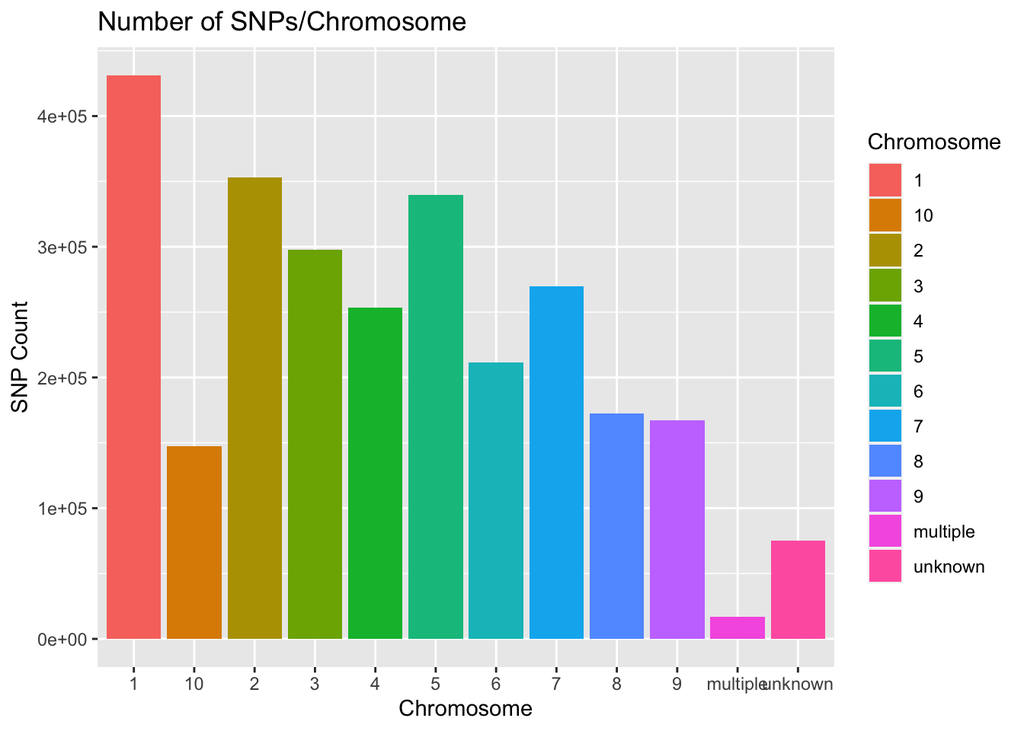

```r
ggplot(joined_genotypes) + geom_bar(aes(x=Chromosome, fill=Chromosome)) + ggtitle("Number of SNPs/Chromosome") + labs(x="Chromosome",y="SNP Count")
```

#Comment: Again, I edited “genotype” to “genotypes” and the chunk runs great. The chromosome with the highest number of SNPs was chromosome 1. ## Heterozygosity Melted and joined the data for graphing.

```r
melted_geno<-melt(genotypes, id = c("Sample_ID", "Group"))
melted_snps<-melt(trimmed_snps, id = c("SNP_ID", "Chromosome"))
colnames(melted_geno)[3:4] <- c("SNP_ID","SNP_Seq")
joined_melted<-merge(melted_snps, melted_geno, by.x = 1, by.y = 3)
joined_melted<-joined_melted[,-3]
```

I added SNP_Status column and coding ?/? to NA, Homozygous to Hom, and Heterozygous to Het

```r
joined_melted$SNP_Status<-"NA"
joined_melted$SNP_Status<-joined_melted$SNP_Seq
joined_melted$SNP_Status[joined_melted$SNP_Status=="?/?"]<- "NA"
joined_melted$SNP_Status[joined_melted$SNP_Status=="A/A" | joined_melted$SNP_Status=="C/C" | joined_melted$SNP_Status=="G/G" | joined_melted$SNP_Status=="T/T"] <- "Hom"
joined_melted$SNP_Status[joined_melted$SNP_Status!="Hom" & joined_melted$SNP_Status!="NA"] <- "Het"
recoded_genotype<-joined_melted
sort_recoded<-arrange(recoded_genotype, Group, Sample_ID)
```

#Comment: changed “recoded_geno” to “recoded_genotype” Graphing

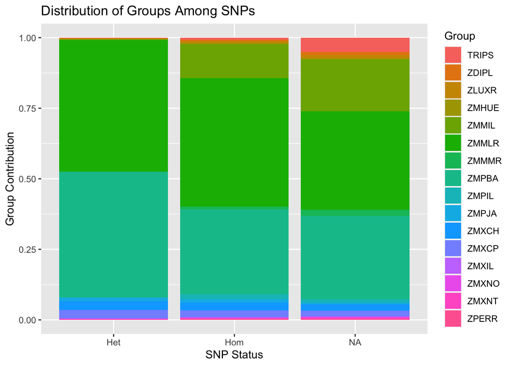

```r
ggplot(recoded_genotype) + geom_bar(aes(x=SNP_Status, fill=Group), position = "fill") + ggtitle("Distribution of Groups Among SNPs") + labs(x="SNP Status",y="Group Contribution")
```

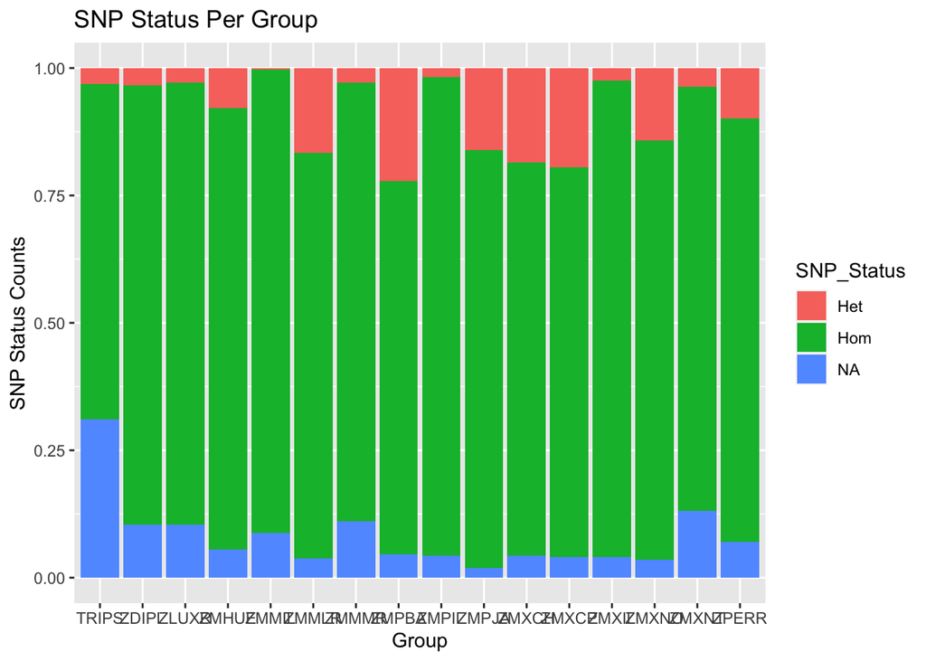

```r
ggplot(recoded_genotype) + geom_bar(aes(x=Group, fill=SNP_Status), position = "fill") + ggtitle("SNP Status Per Group") + labs(x="Group",y="SNP Status Counts")
```

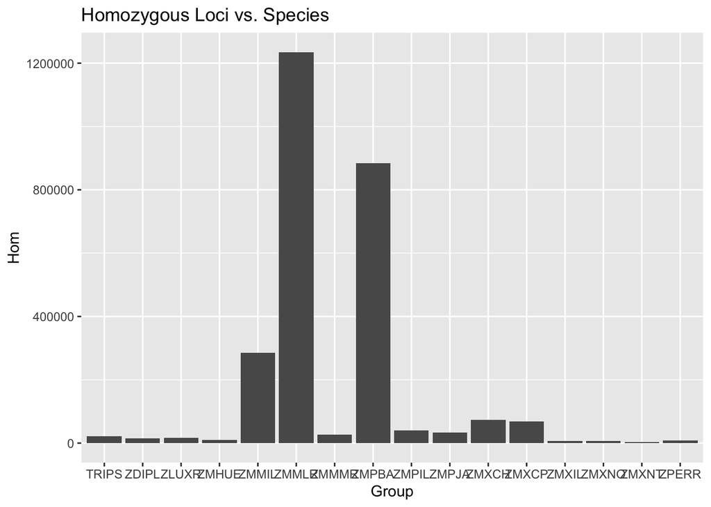

```r
ggplot(recoded_genotype) + geom_bar(aes(x=Group)) + ggtitle("Homozygous Loci vs. Species") + labs(x="Group",y="Hom")
```

#Other comments: Your output files did load to my computer, which is good. However, some of them had no data, only headers. And the ones that did have data were not correctly sorted by position. #It looks like your positions sorted alphabetically, not numerically, probably because your “Position” column was in character form. #Changing the “Position” column to numeric via as.numeric() would probably solve this problem. #But overall your script is good! It ran smoothly on my computer and your visualizations are nice.